```r
library(caret)
library(ggplot2)
library(dplyr)
library(reshape)
library(Hmisc)
library(AppliedPredictiveModeling)
library(rattle)
```

# Overview

The data used in this project is the Weight Lifting Exercise Dataset from Velloso, E.; Bulling, A.; Gellersen, H.; Ugulino, W.; Fuks, H. Qualitative Activity Recognition of Weight Lifting Exercises, in Proceedings of 4th International Conference in Cooperation with SIGCHI (Augmented Human '13) Stuttgart, Germany: ACM SIGCHI, 2013. This paper is viewable online at http://web.archive.org/web/20161224072740/http:/groupware.les.inf.puc-rio.br/har

The data comprise measurements from accelerometers on the belt, forearm, arm, and dumbell of 6 users performing barbell lifts correctly and incorrectly in 5 different ways, coded as "A" to "E" in the data. This project seeks to build a classifier that can predict the manner in which the activity was carried out.

# Data

The original data are available for download at the following url: https://d396qusza40orc.cloudfront.net/predmachlearn/pml-training.csv

To reproduce this report please first download the above into a directory named "data".

```r
data <- read.csv("data/training.csv", stringsAsFactors = FALSE)
```

We first exclude irrelevant rows and columns from the data, remove variables that have one or very few unique values, and then partition the cleaned data into a training, test and validation sets.

```r
# remove columns without predictive value
drop_columns <- c("X",
                  "user_name",
                  "raw_timestamp_part_1",
                  "raw_timestamp_part_2",
                  "cvtd_timestamp",
                  "new_window",
                  "num_window")

data_cleaned <- data %>%
  filter(new_window == "no") %>%
  select(-starts_with("avg")) %>%
  select(-starts_with("var")) %>%
  select(-starts_with("stddev")) %>%
  select(-one_of(drop_columns))

# remove variables with zero or near zero variance from the set of predictors
data_cleaned_predictors <- data_cleaned %>%
  select(-matches("classe"))

data_cleaned_predictors <- data.frame(lapply(data_cleaned_predictors, as.numeric))
nz <- nearZeroVar(data_cleaned_predictors)
data_cleaned_predictors <- data_cleaned_predictors[, -nz]

# re-combine predictors and results
data_cleaned <- cbind(data_cleaned_predictors, classe = data_cleaned$classe)

# partition data into train, test and validation sets
inTrain <- createDataPartition(data_cleaned$classe, p = 3 / 4)[[1]]
training <- data_cleaned[inTrain,]
remainder <- data_cleaned[-inTrain,]

inTest <- createDataPartition(remainder$classe, p = 1 / 2)[[1]]
testing <- remainder[inTest,]
validation <- remainder[-inTest,]
```

There are a lot of predictors so to visualise them we group by placement of the accelerometer

```r
training_belt <- training %>% select(matches("belt|classe"))
training_arm <- training %>% select(matches("arm|classe"))
training_dumbbell <- training %>% select(matches("dumbbell|classe"))
training_forearm <- training %>% select(matches("forearm|classe"))
```

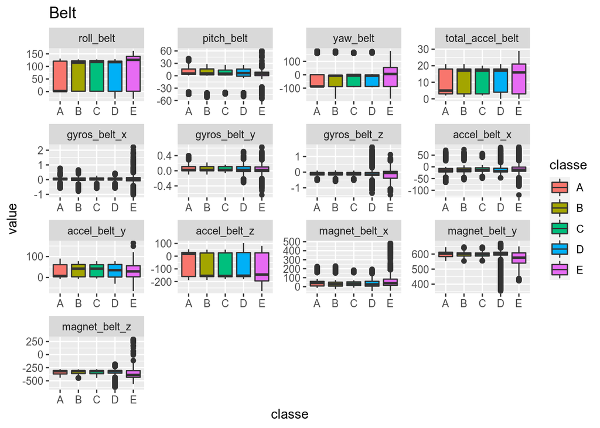

```r
training_belt %>%
  melt(id = "classe") %>%
  ggplot(aes(classe, value, fill = classe)) +
  facet_wrap(~variable, scales = "free") +
  geom_boxplot() +
  ggtitle("Belt")
```

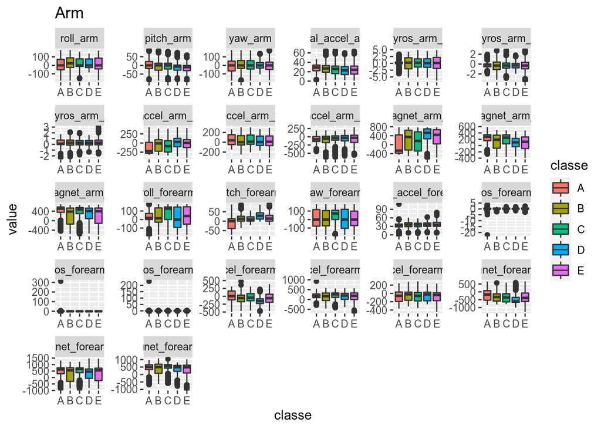

```r
training_arm %>%
  melt(id = "classe") %>%
  ggplot(aes(classe, value, fill = classe)) +
  facet_wrap(~variable, scales = "free") +
  geom_boxplot() +
  ggtitle("Arm")
```

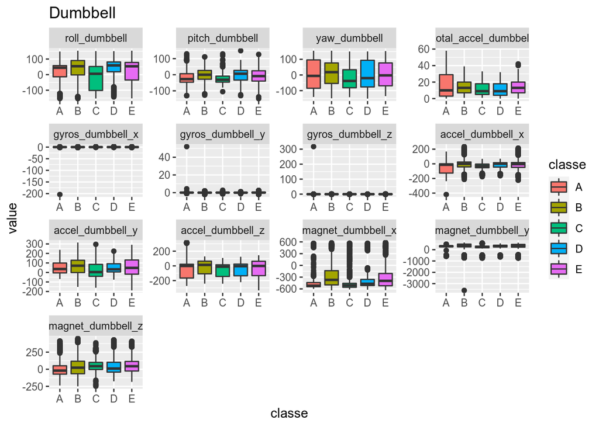

```r
training_dumbbell %>%
  melt(id = "classe") %>%
  ggplot(aes(classe, value, fill = classe)) +
  facet_wrap(~variable, scales = "free") +
  geom_boxplot() +
  ggtitle("Dumbbell")
```

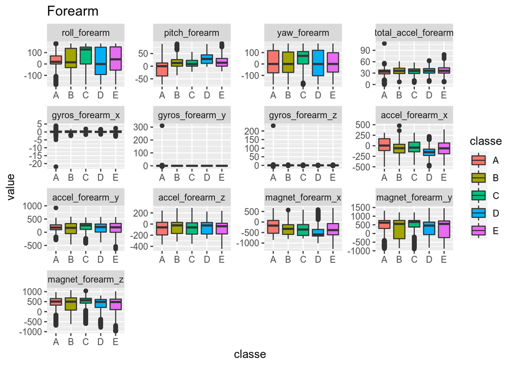

```r
training_forearm %>%
  melt(id = "classe") %>%
  ggplot(aes(classe, value, fill = classe)) +
  facet_wrap(~variable, scales = "free") +
  geom_boxplot() +
  ggtitle("Forearm")
```

We note that quite a few of these metrics are skewed, so we might want to preprocess the data by centering and scaling.

# Model selection

We train three candidate models using decision tree, bagged decision tree, and linear discriminant analysis methods, respectively.

```r
modelFitRPart <- train(classe ~ .,
                       method = "rpart",
                       data = training,
                       preProcess = c("center", "scale"))

modelFitBag <- train(classe ~ .,
                     method = "treebag",
                     data = training,
                     preProcess = c("center", "scale"))

modelFitLda <- train(classe ~ .,
                     method = "lda",
                     data = training,
                     preProcess = c("center", "scale"))
```

To choose between the models we use the testing set:

```r
predictedRPart <- predict(modelFitRPart, testing)
confusionMatrix(testing$classe, predictedRPart)
```

```
## Confusion Matrix and Statistics
##
##           Reference
## Prediction   A   B   C   D   E
##          A 420  94 109  51  10
##          B  86 228  79  72   0
##          C  10  64 338   7   0
##          D  26  81 114 172   0
##          E   7 120  80  31 203
##
## Overall Statistics
##
##                Accuracy : 0.5666
##                  95% CI : (0.5465, 0.5865)
##     No Information Rate : 0.2998
##     P-Value [Acc > NIR] : < 2.2e-16
##
##                   Kappa : 0.4558
##
##  Mcnemar's Test P-Value : < 2.2e-16
##
## Statistics by Class:
##
##                      Class: A Class: B Class: C Class: D Class: E
## Sensitivity            0.7650  0.38842   0.4694  0.51652  0.95305
## Specificity            0.8575  0.86942   0.9518  0.89319  0.89127
## Pos Pred Value         0.6140  0.49032   0.8067  0.43766  0.46032
## Neg Pred Value         0.9249  0.81466   0.8074  0.91986  0.99490
## Prevalence             0.2286  0.24438   0.2998  0.13863  0.08868
## Detection Rate         0.1749  0.09492   0.1407  0.07161  0.08451
## Detection Prevalence   0.2848  0.19359   0.1744  0.16361  0.18360
## Balanced Accuracy      0.8113  0.62892   0.7106  0.70485  0.92216
```

```r
predictedLda <- predict(modelFitLda, testing)
confusionMatrix(testing$classe, predictedLda)
```

```
## Confusion Matrix and Statistics
##
##           Reference
## Prediction   A   B   C   D   E
##          A 563  16  60  44   1
##          B  72 289  54  27  23
##          C  39  55 276  40   9
##          D  18  22  57 275  21
##          E  18  84  38  39 262
##
## Overall Statistics
##
##                Accuracy : 0.6932
##                  95% CI : (0.6743, 0.7116)
##     No Information Rate : 0.2956
##     P-Value [Acc > NIR] : < 2.2e-16
##
##                   Kappa : 0.6116
##
##  Mcnemar's Test P-Value : < 2.2e-16
##
## Statistics by Class:
##
##                      Class: A Class: B Class: C Class: D Class: E
## Sensitivity            0.7930   0.6202   0.5691   0.6471   0.8291
## Specificity            0.9285   0.9091   0.9254   0.9403   0.9142
## Pos Pred Value         0.8231   0.6215   0.6587   0.6997   0.5941
## Neg Pred Value         0.9144   0.9086   0.8946   0.9253   0.9725
## Prevalence             0.2956   0.1940   0.2019   0.1769   0.1316
## Detection Rate         0.2344   0.1203   0.1149   0.1145   0.1091
## Detection Prevalence   0.2848   0.1936   0.1744   0.1636   0.1836
## Balanced Accuracy      0.8607   0.7646   0.7472   0.7937   0.8717
```

```r
predictedBag <- predict(modelFitBag, testing)
confusionMatrix(testing$classe, predictedBag)
```

```
## Confusion Matrix and Statistics
##
##           Reference
## Prediction   A   B   C   D   E
##          A 683   0   0   0   1
##          B   3 457   1   0   4
##          C   0   2 416   1   0
##          D   0   0   9 383   1
##          E   0   0   0   3 438
##
## Overall Statistics
##
##                Accuracy : 0.9896
##                  95% CI : (0.9847, 0.9933)
##     No Information Rate : 0.2856
##     P-Value [Acc > NIR] : < 2.2e-16
##
##                   Kappa : 0.9868
##
##  Mcnemar's Test P-Value : NA
##
## Statistics by Class:
##
##                      Class: A Class: B Class: C Class: D Class: E
## Sensitivity            0.9956   0.9956   0.9765   0.9897   0.9865
## Specificity            0.9994   0.9959   0.9985   0.9950   0.9985
## Pos Pred Value         0.9985   0.9828   0.9928   0.9746   0.9932
## Neg Pred Value         0.9983   0.9990   0.9950   0.9980   0.9969
## Prevalence             0.2856   0.1911   0.1774   0.1611   0.1848
## Detection Rate         0.2843   0.1903   0.1732   0.1595   0.1823
## Detection Prevalence   0.2848   0.1936   0.1744   0.1636   0.1836
## Balanced Accuracy      0.9975   0.9958   0.9875   0.9924   0.9925
```

We pick the bagged model as the clear winner in terms of accuracy.

# Out of sample error

To estimate out of sample error we use the validation set:

```r
predicted <- predict(modelFitBag, validation)
cm <- confusionMatrix(validation$classe, predicted)
```

The estimated accuracy is 0.9879167